# Random forests

Jeffrey Leek, Assistant Professor of Biostatistics

## Random forests

Random Forests is an extension to bootstrap aggregating (bagging) for classifation and reggression trees.

We bootstrap samples, that is, we take a resample of our observed data in our training dataset, and then we rebuild classification or regression trees on each of those bootstrap samples. The one difference is that at each split, when we split the data each time in a classification tree, we also bootstrap the variables. In other words, only a subset of the variables is considered at each potential split. This makes for a diverse set of potential trees that can be built. The idea is that we grow a large number of trees, and then we vote or average those trees in order to get the prediction for a new outcome.

1. Bootstrap samples
2. At each split, bootstrap variables
3. Grow multiple trees and vote

**Pros**:

1. Accuracy

**Cons**:

1. Speed
2. Interpretability
   - You might have a large number of trees that are averaged together, and those trees represent bootstrapped samples with bootstrapped nodes that can be difficult to understand.
3. Overfitting
   - Difficult to know which trees are leading to the overfitting.
   - So it’s very important to use cross validation with it.

## Random forests

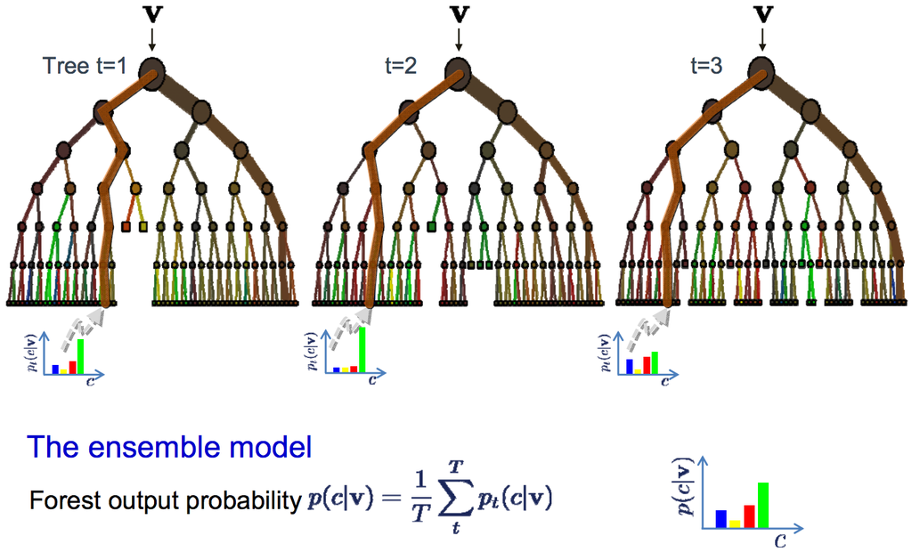

http://www.robots.ox.ac.uk/~az/lectures/ml/lect5.pdf

## Iris data

```r
library(ggplot2); library(caret)
```

```r
data(iris)
inTrain <- createDataPartition(y=iris$Species,
                              p=0.7, list=FALSE)
training <- iris[inTrain,]
testing <- iris[-inTrain,]
```

## Random forests

Here we use the `train()` function from the caret package to fit a model to the training dataset using the random forest method `"rf"`. We use `prox=TRUE`.

```r
modFit <- train(Species~ .,data=training,method="rf",prox=TRUE)
modFit
```

```
Random Forest

105 samples
  4 predictors
  3 classes: 'setosa', 'versicolor', 'virginica'

No pre-processing
Resampling: Bootstrapped (25 reps)

Summary of sample sizes: 105, 105, 105, 105, 105, 105, ...

Resampling results across tuning parameters:

  mtry  Accuracy  Kappa  Accuracy SD  Kappa SD
  2     0.9       0.9    0.03         0.05
  3     0.9       0.9    0.03         0.05
  4     0.9       0.9    0.03         0.05

Accuracy was used to select the optimal model using  the largest value.
The final value used for the model was mtry = 4.
```

In the summary we see that it used bootsrap resampling and that it tried several different tuning parameters. The tuning parameter in particular `mtry` is the number of tries or repeated trees that it’s going to build.

## Getting a single tree

We can look at a specific tree (`k=2`) in our model fit using the `getTree()` function.

```r
getTree(modFit$finalModel,k=2)
```

```
   left daughter right daughter split var split point status prediction
1              2              3         4        0.80      1          0
2              0              0         0        0.00     -1          1
3              4              5         3        4.85      1          0
4              6              7         4        1.65      1          0
5              8              9         4        1.75      1          0
6              0              0         0        0.00     -1          2
7              0              0         0        0.00     -1          3
8             10             11         2        2.65      1          0
9              0              0         0        0.00     -1          3
10             0              0         0        0.00     -1          3
11             0              0         0        0.00     -1          2
```

Each row corresponds to a particular split. For each split, there are variables for the left daughter split, the right daughter split, the variable that we’re splitting on, the value of that split, and that split’s prediction.

## Class “centers”

You can use the “centers” information to would the predictions would be, or the center of the class predictions.

Here we’re looking at petal length versus petal width. We use `classCenter()` to get the class centers, which are the centers for the predicted values. To do that, we specify the variables in the training set that we want, the row labels, and we send it the model fit with the `prox` variable (which we asked for in the previous fitting). We can then plot those class centers to see where they fall in the data. First though, we make those class centers into a data.frame, and make the row.names into a variable `$Species`.

We plot width vs length as solid dots, and color by species. We then plot the class centers as Xs (`shape=4`).

```r
irisP <- classCenter(training[,c(3,4)], training$Species, modFit$finalModel$prox)  ## table of class centers
irisP <- as.data.frame(irisP)
irisP$Species <- rownames(irisP)  ## make row.names into an actual variable.
irisP
```

```
           Petal.Length Petal.Width    Species
setosa             1.50         0.2     setosa
versicolor         4.25         1.3 versicolor
virginica          5.60         2.0  virginica
```

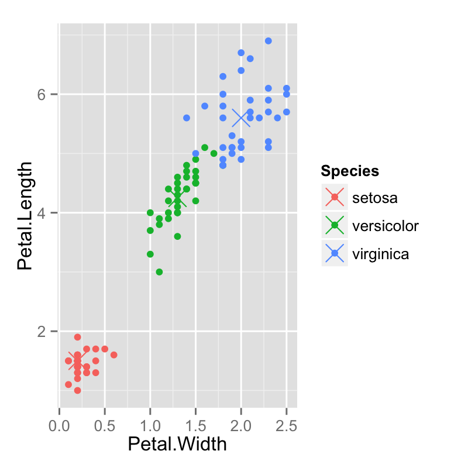

```r
p <- qplot(Petal.Width, Petal.Length, col=Species,data=training)
p + geom_point(aes(x=Petal.Width,y=Petal.Length,col=Species),size=5,shape=4,data=irisP)
```

So you can see that the class centers are the center points or averages of each species group.

## Predicting new values

We can then predict new values, using the test set.

```r
pred <- predict(modFit,testing) ## list of predictions of species (a factor w/ 3 levels)
### Our test set of course contains the correct answers,
### so we can compare those to our predictions:
testing$predRight <- pred==testing$Species
table(pred,testing$Species)
```

```
pred         setosa versicolor virginica
  setosa         15          0         0
  versicolor      0         15         2
  virginica       0          0        13
```

## Predicting new values

Here we plot our predictions against the observations to see which were wrong.

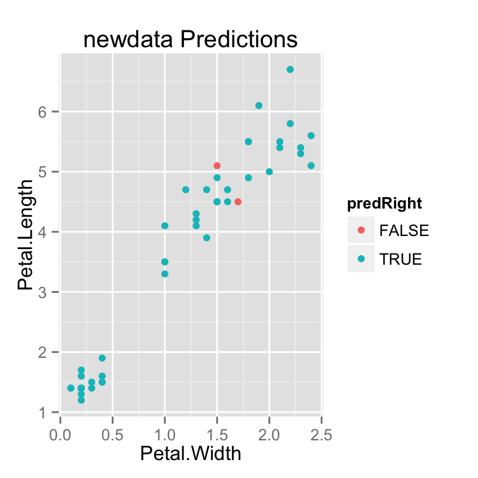

```r
qplot(Petal.Width,Petal.Length,colour=predRight,data=testing,main="newdata Predictions")
```

We can see the one(s) that were wrong fall right on the border between two of the groups.

## Notes and further resources

**Notes**:

- Random forests are usually one of the two top performing algorithms along with boosting in prediction contests.
- Random forests are difficult to interpret but often very accurate.
- Care should be taken to avoid overfitting (see [rfcv](http://cran.r-project.org/web/packages/randomForest/randomForest.pdf) funtion)

**Further resources**:

- [Random forests](http://www.stat.berkeley.edu/~breiman/RandomForests/cc_home.htm)
- [Random forest Wikipedia](http://en.wikipedia.org/wiki/Random_forest)
- [Elements of Statistical Learning](http://www-stat.stanford.edu/~tibs/ElemStatLearn/)